# hackathon

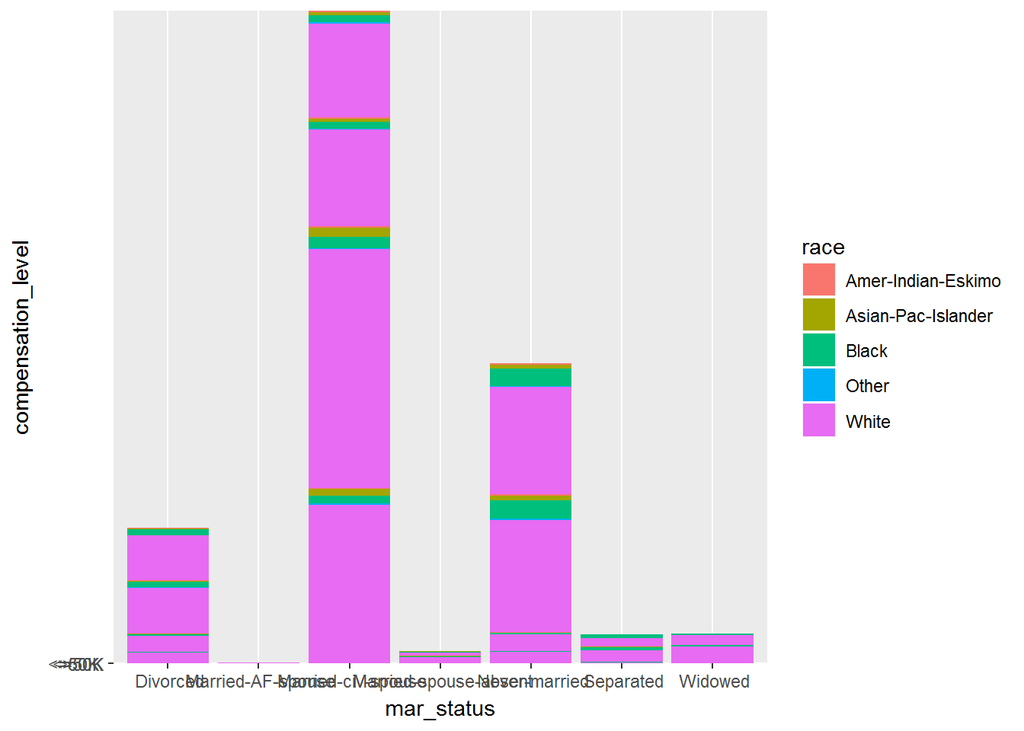

```r
# employees working in private sector falls in category of "compensation more than 50k" compare to local-gov and self-emp-not-inc

ggplot(model_data,aes(x=mar_status,y=compensation_level,fill=race))+geom_bar(stat = "identity")
```

```r
# married-civ-spouse gets higher compensation level and making comparison in people race we get to know that white people get more compensation compare to other race people
```

DATA IMPUTATION

model_new_data <- read.csv(“Model_Data.csv”)

model_new_data$workclass <- gsub("?",NA,model_new_data$workclass, fixed = TRUE) model_new_data$occupation <- gsub("?",NA,model_new_data$occupation, fixed = TRUE)

model_new_data$occupation[is.na(model_new_data$occupation)]=Mode(model_new_data$occupation) model_new_data$workclass[is.na(model_new_data$workclass)]=Mode(model_new_data$workclass) Mode <- function(v) { uniqv <- unique(v) uniqv[which.max(tabulate(match(v, uniqv)))] }

model_new_data$comp_new_level <- gsub("\\.", "",model_new_data$compensation_level) model_new_data$comp_new_level <- as.factor(model_new_data$comp_new_level) model_new_data <- model_new_data[,-c(14,15)] #######################################################################################################

`DECISION TREE`

6.Build 3 Models, each using one of different type of algorithm. Send me the model building command.

`````MODEL 1 = DECISION TREE`

set.seed(28) train_data <- sample.int(n = nrow(model_new_data), size =floor( 0.8 *nrow(model_new_data)),replace = F)

train <- model_new_data[train_data, ] test <- model_new_data[-train_data, ]

train_model <- tree(comp_new_level ~.,train)

plot(train_model) text(train_model)

check_model <- predict(train_model,test) check_model

maxidx <- function(arr) { return(which(arr==max(arr))) } idx <- apply(check_model,c(1),maxidx) predict_model <- c(‘No’,‘Yes’)[idx]

confmat <- table(predict_model,test$comp_new_level) confmat confusion matrix

accuracy <- sum(diag(confmat))/sum(confmat) accuracy

ACCURACY = 0.8388021

``MODEL 2 =Naive Bayes`

```r
library(e1071)
model_new_data <- read.csv("Model_Data.csv")
model_new_data$comp_new_level <- gsub("\\.", "",model_new_data$compensation_level)
model_new_data$comp_new_level <- as.factor(model_new_data$comp_new_level)
model_new_data <- model_new_data[,-15]
set.seed(28)


sample <- sample.int(n=nrow(model_new_data),size = floor(0.8*nrow(model_new_data)),replace = F)

train_data <- model_new_data[sample,]
test_data <- model_new_data[-sample,]

model <- naiveBayes(comp_new_level ~ age+workclass+fnlwgt+edu+edu_num+mar_status+occupation+race+Hours_per_week+country,data = train_data)
#model

pred <- predict(model,test_data)
#pred
#chechking and creating conf matrix with pred values and labelled variable values
confmat <- table(pred,test_data$comp_new_level)
confmat
```

```
##
## pred      <=50K  >50K
##    <=50K   5082   687
##    >50K     724  1187
```

```r
#checking accuracy
accuracy <- sum(diag(confmat))/sum(confmat)
accuracy
```

```
## [1] 0.816276
```

`````````````MODEL 3=kNN``````````````

```r
library(class)
set.seed(28)
sample <- sample.int(nrow(model_new_data),size = floor(0.80*(nrow(model_new_data))),replace = FALSE)

train <- model_new_data[sample,c(1,3,5,11,12,13)]
test <- model_new_data[-sample,c(1,3,5,11,12,13)]
train_label <-model_new_data[sample,14]
test_label <-model_new_data[-sample,14]

k=5
pred_label <- knn(train = train,test = test,cl =train_label,k )

confmat=table(test_label,pred_label)

accuracy <- sum(diag(confmat))/sum(confmat)
accuracy
```

```
## [1] 0.8933594
```

Country column didnt had any major impact on labelled variable so have ignored column to build the model

7.Predict your model performance on each of the 3 models and submit ( 1 mark each = total 3 marks) model1_accuracy= 0.8388021 model2_accuracy =0.816276 modell3_accuracy=0.8933594

8.Generalization:-

All Model accuracy are between 75-90 % so my model are not underfit and overfit

[output not shown]